# DS-HW[1] Data Parsing and Cleansing

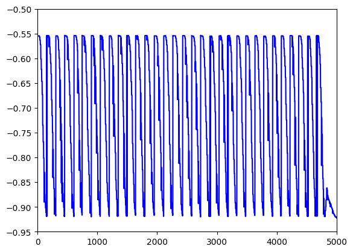

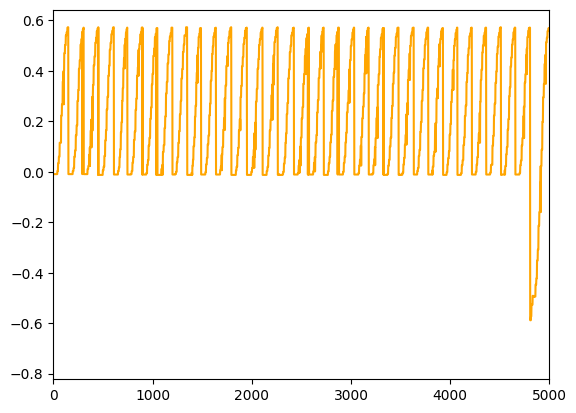

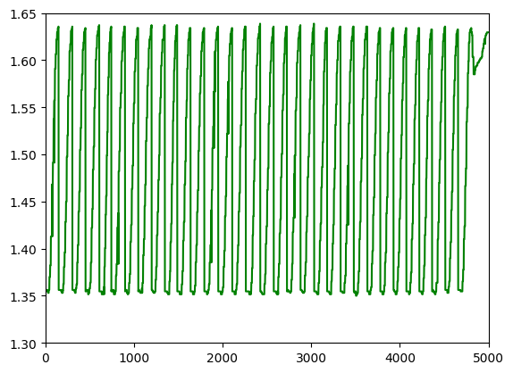

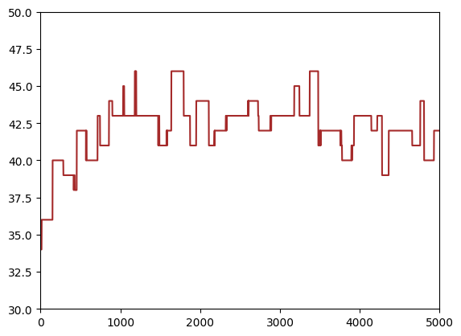

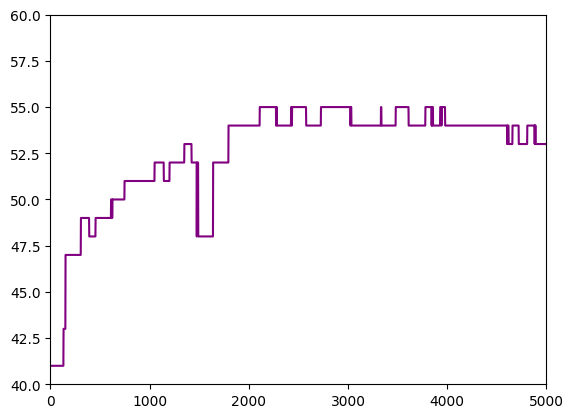

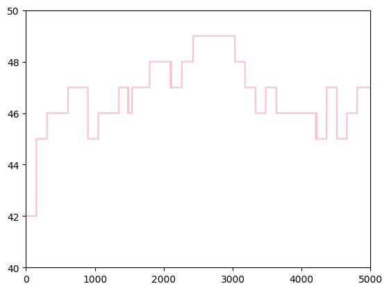

```python
# 최소값으로 데이터 cleansing 진행한 대한 그래프 플롯

# ang_j3 그래프 플롯
data['ang_j3'].plot(color='blue')
plt.xlim([0, 5000])
plt.ylim([-0.95, -0.50])
plt.show()

# ang_j4 그래프 플롯
data['ang_j4'].plot(color='orange')
plt.xlim([0, 5000])
plt.show()

# ang_j5 그래프 플롯
data['ang_j5'].plot(color='green')
plt.xlim([0, 5000])
plt.ylim([1.3, 1.65])
plt.show()

# temp_j3 그래프 플롯
data['temp_j3'].plot(color='brown')
plt.xlim([0, 5000])
plt.ylim([30, 50])
plt.show()

# temp_j4 그래프 플롯
data['temp_j4'].plot(color='purple')
plt.xlim([0, 5000])
plt.ylim([40, 60])
plt.show()

# temp_j5 그래프 플롯
data['temp_j5'].plot(color='pink')
plt.xlim([0, 5000])
plt.ylim([40, 50])
plt.show()
```

=> 5가지 결측값 대체 방법에 대하여 진행한 결과를 각각 그래프로 나타내었다. 먼저 median() 방법을 이용하여 결측값을 제거하였을 때, 그래프의 형태가 가장 매끄럽게 잘 나타난 것을 알 수 있다. 이에 따라 데이터 cleansing에 있어서, 우선적으로 결측값을 중간값으로 대체하는 것이 가장 효율적인 방법으로 판단되어 진다. 그리고 평균값, 최대값, 최소값으로 결측값을 대체한 방법은 중간값 대체에 비해 상대적으로 그래프의 형태가 매끄럽지 않고, 중간중간 굵은 부분이 보이는 것을 통해 대체 방법으로 적절하지 않은 것으로 판단할 수 있다. 이어서 dropna()를 활용하여 결측값을 제거한 방법은 데이터의 값을 지울 수 있어 좋지만, 값의 연결이 매끄럽지 않고 데이터의 규칙성이 깨질 우려가 있기 때문에 중간값 대체보다 효율적인 방법은 아니라고 생각한다.

따라서 5가지의 결측값 대체 방법 중 중앙값을 활용한 방법이 가장 활용적이라고 할 수 있고, 해당 방법을 통해 대체한 데이터프레임을 이용하여 data parsing 작업을 진행할 것이다.

## Problem 2. Data Parsing

### 0) Data interval setting considering periodicity of data

A)Analyze periodicity by parameter and set appropriate window size.

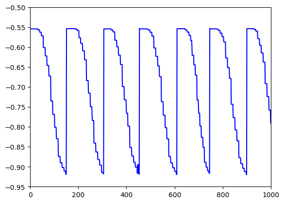

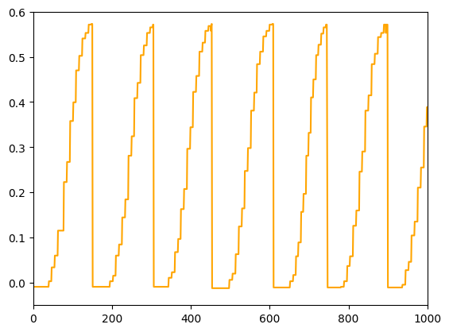

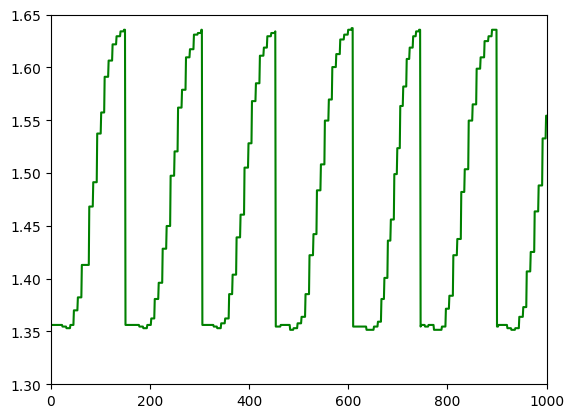

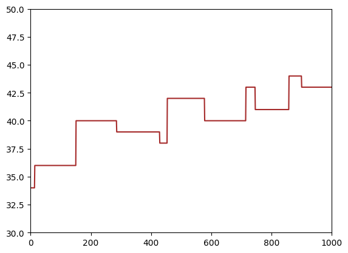

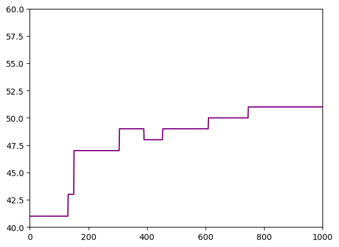

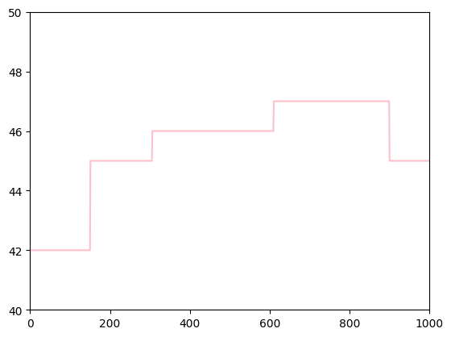

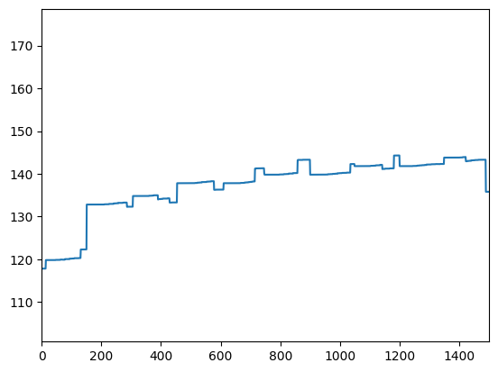

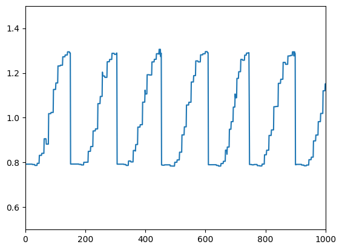

```python
# 각 파라미터 별로 주기성을 잘 확인할 수 있도록 그래프 플롯

# ang_j3 그래프 플롯
data['ang_j3'].plot(color='blue')
plt.xlim([0, 1000])
plt.ylim([-0.95, -0.50])
plt.show()

# ang_j4 그래프 플롯
data['ang_j4'].plot(color='orange')
plt.xlim([0, 1000])
plt.ylim([-0.05, 0.6])
plt.show()

# ang_j5 그래프 플롯
data['ang_j5'].plot(color='green')
plt.xlim([0, 1000])
plt.ylim([1.3, 1.65])
plt.show()

# temp_j3 그래프 플롯
data['temp_j3'].plot(color='brown')
plt.xlim([0, 1000])
plt.ylim([30, 50])
plt.show()

# temp_j4 그래프 플롯
data['temp_j4'].plot(color='purple')
plt.xlim([0, 1000])
plt.ylim([40, 60])
plt.show()

# temp_j5 그래프 플롯
data['temp_j5'].plot(color='pink')
plt.xlim([0, 1000])
plt.ylim([40, 50])
plt.show()

# 6가지의 파라미터를 합친 그래프 플롯
data['sum1'] = data['ang_j3'] + data['ang_j4'] + data['ang_j5'] + data['temp_j3'] + data['temp_j4'] + data['temp_j5']
plt.plot(data['sum1'])
plt.xlim([0, 1500])
plt.show()

# 각도 파라미터 3개를 합친 그래프 플롯
data['sum2'] = data['ang_j3'] + data['ang_j4'] + data['ang_j5']
plt.plot(data['sum2'])
plt.xlim([0, 1000])
plt.ylim([0.5, 1.5])

# window 사이즈 설정
window_size=160
```

=> 중앙값으로 data cleansing을 진행한 데이터프레임으로 값이 반복되는 구간을 찾기 위해, 파라미터 별로 일정 범위의 데이터를 플롯하였다.

각도 파라미터인 'ang_j3', 'ang_j4', 'ang_j5'는 일정 구간 별로 반복되는 구간이 존재하여, 주기성을 쉽게 찾을 수 있다.하지만 온도 파라미터인 'temp_j3', 'temp_j4', 'temp_j5'는 반복되는 구간을 확인하기 어려우므로, 주기성이 존재한다고 할 수 없다.

B) Assign window_idx sequentially from 1.

```python
# motion_id가 4에서 30으로 바뀌는 지점을 저장하기 위한 변수
length = 0

# motion_id에서 4와 30의 경계 인덱스 파악
for i in range(0, len(data)):
    if data['motion_id'][i] == 4:
        length = i + 1

# motion_id가 4인 배열에 대해서 window_index 부여
window_idx = np.arange(len(data)) // window_size + 1

# motion_id가 30인 배열에 대해서 window_index 부여
for i in range(length, len(data)):
    window_idx[i] = (i - length) // window_size + 1

# 부여한 window_idx 확인
print(window_idx[:length])
print(window_idx[length:])
```

```
[   1    1    1 ... 5780 5780 5780]
[   1    1    1 ... 4529 4529 4529]
```

=> 데이터프레임에서 motion_id가 4에서 30으로 바뀌는 구간은 length번째 행이며, 이를 기준 으로 두 구간으로 나누어 window_index를 부여하였다. numpy의 arange를 이용하여 window_ index를 부여하였으며, 각 행을 window_size로 나누고 1을 더하는 과정으로 진행하였다.

그리고 motion_id가 4인 구간에선 window_index가 5780까지 생성되었고, motion_id가 30인 구간에선 4529까지 생성된 것을 확인하였다.

C) Create a 'window_idx' column in the dataframe and index the assigned number.

```python
# 엑셀 csv 파일에 'window_idx'라는 열 추가
data['window_idx'] = window_idx

# motion_id가 4인 구간에서 데이터프레임 값 확인
print(data[0:length])

# motion_id가 30인 구간에서 데이터프레임 값 확인
print(data[length:])
```

```
                tick    ang_j3    ang_j4   ang_j5  temp_j3  temp_j4  temp_j5  \
0       160049320050 -0.554516 -0.009215  1.35619     34.0     41.0     42.0
1       160049320051 -0.554516 -0.009215  1.35619     34.0     41.0     42.0
2       160049320053 -0.554516 -0.009215  1.35619     34.0     41.0     42.0
3       160049320054 -0.554516 -0.009215  1.35619     34.0     41.0     42.0
4       160049320056 -0.554516 -0.009215  1.35619     34.0     41.0     42.0
...              ...       ...       ...      ...      ...      ...      ...
924700  160181712923 -0.919041  0.568279  1.61422     45.0     55.0     50.0
924701  160181712923 -0.919041  0.568279  1.61422     45.0     55.0     50.0
924702  160181712923 -0.919041  0.568279  1.61422     45.0     55.0     50.0
924703  160181712923 -0.919041  0.568279  1.61422     45.0     55.0     50.0
924704  160181712923 -0.919041  0.568279  1.61422     45.0     55.0     50.0

        motion_id        sum1      sum2  window_idx
0               4  117.792459  0.792459           1
```

[output cut: 39 more lines]

=> 위의 코드를 통해 데이터프레임에 'window_idx'라는 열을 추가하여, 각 행마다 window_ index를 대입하도록 하였다.

length를 기준으로 motion_id가 4인 구간과 30인 구간의 데이터프레임 값을 확인해본 결과, 데이터프레임의 924704 행까지 motion_id가 4이며, 그 이후로는 30인 것을 확인하였 다. 결국 motion_id 별로 구간이 잘 나누어졌고, window_idx 별로 구간도 잘 나누어진 것 을 확인할 수 있다.

### 1) Parsing ‘Random Interval’

A) Generate two random integer numbers according to the number of window_idx per motion_id.

```python
# 랜덤하게 뽑은 두 수를 저장할 리스트(motion_id가 4인 것과 30인 것)
num_list1 = []
num_list2 = []

# motion_id가 4인 데이터프레임의 마지막 인덱스 파악
window_idx1 = data['window_idx'][length - 1]
# motion_id가 30인 데이터프레임의 마지막 인덱스 파악
window_idx2 = data['window_idx'][len(data) - 1]

# 각 motion_id 별로 랜덤한 정수 2개 생성
num_list1 = np.random.randint(window_idx1 + 1, size = 2)
num_list2 = np.random.randint(window_idx2 + 1, size = 2)

# 랜덤 정수 오름차순 정렬
num_list1.sort()
num_list2.sort()

print(window_idx1)
print(window_idx2)
print(num_list1)
print(num_list2)
```

```
5780
4529
[4921 5245]
[1203 1329]
```

=> 위는 motion_id 별로 각각 0부터 window_idx 범위 사이에서 랜덤한 두 수를 뽑는 과정이다 . 랜덤하게 뽑은 두 수를 저장하기 위해, num_list1과 num_list2 라는 두 개의 리스트를 선언하였으며, window_idx1과 window_idx2에 각각 motion_id가 4일 때와 30일 때의 최대 window_idx 값을 담았다. 그리고 뽑은 두 수를 sort() 함수를 통해 오름차순으로 정렬하여 이후에 데이터를 parsing하기 편하도록 하였다.

window_idx1, window_idx2는 각각 5780과 4529로 알맞게 나오는 것을 확인할 수 있으며, num_list1과 num_list2에서는 작은 수와 큰 수가 차례대로 올바르게 나오는 것을 확인할 수 있다.

B) Parsing the data for the interval between the two values of A) for each parameter.

```python
# data에 저장된 데이터프레임 복사
parsedData1 = data.copy()
parsedData2 = data.copy()

# motion_id 별로, 랜덤하게 뽑은 두 수 사이에서 데이터프레임 parsing
parsedData1 = parsedData1.loc[(data['window_idx'] >= num_list1[0]) & (data['window_idx'] <= num_list1[1]), ['ang_j3', 'ang_j4', 'ang_j5', 'temp_j3', 'temp_j4', 'temp_j5']]
parsedData2 = parsedData2.loc[(data['motion_id'] == 30) & (data['window_idx'] >= num_list2[0]) & (data['window_idx'] <= num_list2[1]), ['ang_j3', 'ang_j4', 'ang_j5', 'temp_j3', 'temp_j4', 'temp_j5']]

# parsing한 데이터 출력
print(parsedData1)
print(parsedData2)
```

```
          ang_j3    ang_j4   ang_j5  temp_j3  temp_j4  temp_j5
787200 -0.554516 -0.009215  1.31011     48.0     48.0     52.0
787201 -0.554516 -0.009215  1.31011     48.0     48.0     52.0
787202 -0.554516 -0.009215  1.31011     48.0     48.0     52.0
787203 -0.554516 -0.009215  1.31011     48.0     48.0     52.0
787204 -0.554516 -0.009215  1.31011     48.0     48.0     52.0
...          ...       ...      ...      ...      ...      ...
839195 -0.754481  0.354791  1.53743     39.0     47.0     43.0
839196 -0.754481  0.354791  1.53743     39.0     47.0     43.0
839197 -0.754481  0.354791  1.53743     39.0     47.0     43.0
839198 -0.754481  0.354791  1.53743     39.0     47.0     43.0
839199 -0.754481  0.354791  1.53743     39.0     47.0     43.0

[52000 rows x 6 columns]
           ang_j3    ang_j4   ang_j5  temp_j3  temp_j4  temp_j5
1117025 -0.727553  0.394724  1.49442     41.0     52.0     47.0
1117026 -0.727553  0.394724  1.49442     41.0     52.0     47.0
1117027 -0.727553  0.394724  1.49442     41.0     52.0     47.0
1117028 -0.727553  0.394724  1.49442     41.0     52.0     47.0
1117029 -0.727553  0.394724  1.49442     41.0     52.0     47.0
...           ...       ...      ...      ...      ...      ...
1137340 -0.784401  0.208881  1.53282     47.0     57.0     50.0
1137341 -0.785897  0.210417  1.53282     47.0     57.0     50.0
1137342 -0.785897  0.210417  1.53282     47.0     57.0     50.0
1137343 -0.785897  0.210417  1.53282     47.0     57.0     50.0
1137344 -0.785897  0.210417  1.53282     47.0     57.0     50.0

[20320 rows x 6 columns]
```

=> 이전 단계에서 뽑은 랜덤한 두 수를 이용하여 데이터프레임 값을 parsing 하였다.

먼저 motion_id가 4인 부분은 parsedData1에 데이터를 parsing 하였으며, 뽑은 난수인 num _list1[0]과 num_list1[1] 사이의 범위에서 값을 parsing 하도록 하였다.

다음으로 motion_id가 30인 부분은 parsedData2에 데이터를 parsing 하였으며, num_list2 [0]과 num_list2[1] 사이의 범위에서 데이터프레임을 parsing 하도록 하였다.

parsing한 데이터인 parsedData1과 parsedData2를 출력한 결과, 올바른 구간에서 값이 나오는 것을 확인할 수 있다.

C) Organize the result data to data type “dict” with Key and Value

```python
# 데이터프레임에 저장된 열 이름을 변경
parsedData1 = parsedData1.rename(columns={'ang_j3':'Motion4_AngleJoint3', 'ang_j4':'Motion4_AngleJoint4', 'ang_j5':'Motion4_AngleJoint5', 'temp_j3':'Motion4_TempJoint3', 'temp_j4':'Motion4_TempJoint4', 'temp_j5':'Motion4_TempJoint5'})
parsedData2 = parsedData2.rename(columns={'ang_j3':'Motion30_AngleJoint3', 'ang_j4':'Motion30_AngleJoint4', 'ang_j5':'Motion30_AngleJoint5', 'temp_j3':'Motion30_TempJoint3', 'temp_j4':'Motion30_TempJoint4', 'temp_j5':'Motion30_TempJoint5'})

# 데이터프레임을 딕셔너리 형태로 변환
parsedData_dict1 = parsedData1.to_dict()
parsedData_dict2 = parsedData2.to_dict()

# 두 딕셔너리를 하나로 합치기
parsedData_dict1.update(parsedData_dict2)

# 딕셔너리 출력
parsedData_dict1
```

```
{'Motion4_AngleJoint3': {787200: -0.554516,
  787201: -0.554516,
  787202: -0.554516,
  787203: -0.554516,
  787204: -0.554516,
  787205: -0.554516,
  787206: -0.554516,
  787207: -0.554516,
  787208: -0.554516,
  787209: -0.554516,
  787210: -0.554516,
  787211: -0.554516,
  787212: -0.554516,
  787213: -0.554516,
  787214: -0.554516,
```

[output cut: 11997 more lines]

=> rename() 함수를 통해, 데이터프레임에 파라미터 이름을 바꾸어 저장하였다. 또한 to_dict()를 이용하여 데이터프레임을 딕셔너리 형태로 바꾸어 저장하였다.

하나로 합친 parsedData_dict1을 선언하여 출력을 진행하면 parsing한 데이터가 올바르게 추출되는 것을 확인할 수 있다.

D) Save the result as a json file.

```python
import json

col = ['Motion4_AngleJoint3', 'Motion4_AngleJoint4', 'Motion4_AngleJoint5', 'Motion4_TempJoint3', 'Motion4_TempJoint4', 'Motion4_TempJoint5', 'Motion30_AngleJoint3', 'Motion30_AngleJoint4', 'Motion30_AngleJoint5', 'Motion30_TempJoint3', 'Motion30_TempJoint4', 'Motion30_TempJoint5']
cnt = 0

for j in col:
    # motion_id가 4인 json 파일 생성
    if cnt < 6:
        with open('ds_hw1_randomInterval_(4)_(' + str(j) + ')_('+ str(num_list1[0]) + '~' + str(num_list1[1]) + ').json', 'w') as json_file:
            json.dump(parsedData_dict1[j], json_file)
    # motion_id가 30인 json 파일 생성
    else:
        with open('ds_hw1_randomInterval_(30)_(' + str(j) + ')_('+ str(num_list2[0]) + '~' + str(num_list2[1]) + ').json', 'w') as json_file:
            json.dump(parsedData_dict1[j], json_file)
    cnt += 1
```

### 2) Parsing ‘Main Execution Interval’

A) Find the index with the median value for each parameter

```python
import statistics as st

# 각 motion_id 별로 window_index의 최대값 저장
window_idx1 = data['window_idx'][length - 1]
window_idx2 = data['window_idx'][len(data) - 1]

# 파라미터 별로 각 window_idx의 평균값들을 저장할 딕셔너리
avg_data1 = {'ang_j3': [], 'ang_j4': [], 'ang_j5': [], 'temp_j3': [], 'temp_j4': [], 'temp_j5': []}
avg_data2 = {'ang_j3': [], 'ang_j4': [], 'ang_j5': [], 'temp_j3': [], 'temp_j4': [], 'temp_j5': []}

# 각 파라미터 별로 window_idx 평균들의 중앙값을 저장할 리스트
median_list1 = []
median_list2 = []

# 각 파라미터 별로 중앙값의 인덱스를 담을 딕셔너리
index_list1 = {'ang_j3': [], 'ang_j4': [], 'ang_j5': [], 'temp_j3': [], 'temp_j4': [], 'temp_j5': []}
index_list2 = {'ang_j3': [], 'ang_j4': [], 'ang_j5': [], 'temp_j3': [], 'temp_j4': [], 'temp_j5': []}

columns = ['ang_j3', 'ang_j4', 'ang_j5', 'temp_j3', 'temp_j4', 'temp_j5']

# motion_id가 4일 때 중앙값 및 인덱스 구하기
for col in columns:
    # 각 window_index 별로 평균값 구하기
    for k in range(1, window_idx1):
        avg1 = round(data[col].loc[data['window_idx'] == k].mean(), 3)
        avg_data1[col].append(avg1)
    # 중앙값을 구하여 리스트에 넣기
    med1 = st.median(avg_data1[col])
    median_list1.append(med1)
    if med1 in avg_data1[col]:
        index_list1[col] = avg_data1[col].index(med1)
    else:
        index_list1[col] = 500

# motion_id가 30일 때 중앙값 및 인덱스 구하기
for col in columns:
    # 각 window_index 별로 평균값 구하기
    for k in range(1, window_idx2 + 1):
        avg2 = round(data[col].loc[data['window_idx'] == k].mean(), 3)
        avg_data2[col].append(avg2)
    # 중앙값을 구하여 리스트에 넣기
    med2 = st.median(avg_data2[col])
    median_list2.append(med2)
    if med2 in avg_data2[col]:
        index_list2[col] = avg_data2[col].index(med2)

# window_index, 파라미터 별 중앙값 리스트, 각 중앙값의 인덱스 출력
print(window_idx1)
print(window_idx2)
print(median_list1)
print(median_list2)
print(index_list1)
print(index_list2)
```

```
5780
4529
[-0.719, 0.243, 1.46, 44.0, 54.0, 53.988]
[-0.723, 0.25, 1.464, 43.7, 54.0, 52.844]
{'ang_j3': 1, 'ang_j4': 430, 'ang_j5': 429, 'temp_j3': 114, 'temp_j4': 12, 'temp_j5': 4246}
{'ang_j3': 682, 'ang_j4': 149, 'ang_j5': 63, 'temp_j3': 1138, 'temp_j4': 12, 'temp_j5': 2136}
```

=> 위의 과정은 각 윈도우 인덱스 별로 평균값을 구하고, 구한 평균값들 중에서 중간값과 그에 대한 인덱스를 구하는 과정이다.

순차적으로 window_index의 크기, 파라미터 별 중간값, 중간값의 인덱스 리스트를 출력하였을 때, 위와 같이 결과 값을 확인할 수 있다.

B) Extract data as much as 10% of the total window length back and forth around the index of A) for each parameter.

```python
# 각 motion_id 별로, 전체 window_index의 10% 길이 구하기
length1 = int((window_idx1) * 0.1)
length2 = int((window_idx2) * 0.1)

parsedData_dict3 = {'Motion4_AngleJoint3': [], 'Motion4_AngleJoint4': [], 'Motion4_AngleJoint5': [], 'Motion4_TempJoint3': [], 'Motion4_TempJoint4': [], 'Motion4_TempJoint5': []}
parsedData_dict4 = {'Motion30_AngleJoint3': [], 'Motion30_AngleJoint4': [], 'Motion30_AngleJoint5': [], 'Motion30_TempJoint3': [], 'Motion30_TempJoint4': [], 'Motion30_TempJoint5': []}

new_col1 = ['Motion4_AngleJoint3', 'Motion4_AngleJoint4', 'Motion4_AngleJoint5', 'Motion4_TempJoint3', 'Motion4_TempJoint4', 'Motion4_TempJoint5']
new_col2 = ['Motion30_AngleJoint3', 'Motion30_AngleJoint4', 'Motion30_AngleJoint5', 'Motion30_TempJoint3', 'Motion30_TempJoint4', 'Motion30_TempJoint5']

# 파싱 구간의 양쪽 인덱스를 담을 리스트
interval_index1 = []
interval_index2 = []

# 중앙값을 기준으로 정렬하는 과정
for col in columns:
    avg_data1[col][:index_list1[col]].sort()
    avg_data1[col][index_list1[col] + 1:].sort()
    avg_data2[col][:index_list2[col]].sort()
    avg_data2[col][index_list2[col] + 1:].sort()

# motion_id가 4일 때 데이터 parsing 진행
for col, nc in zip(columns, new_col1):
    index1 = index_list1[col]
    # 인덱스 기준으로 앞부분의 데이터 개수가 5% 미만인 경우
    if index1 - length1 // 2 < 0:
        parsedData_dict3[nc].append(avg_data1[col][0:index1 + length1 // 2])
        interval_index1.append(0)
        interval_index1.append(index1 + length1 // 2)
    # 인덱스 기준으로 뒷부분의 데이터 개수가 5% 미만인 경우
    elif index1 + length1 // 2 >= window_idx1:
        parsedData_dict3[nc].append(avg_data1[col][index1 - length1 // 2:len(window_idx1) + 1])
        interval_index1.append(index1 - length1 // 2)
        interval_index1.append(window_idx1)
    else:
        parsedData_dict3[nc].append(avg_data1[col][index1 - length1 // 2:index1 + length1 // 2])
        interval_index1.append(index1 - length1 // 2)
        interval_index1.append(index1 + length1 // 2)


# motion_id가 30일 때 데이터 parsing 진행
for col, nc in zip(columns, new_col2):
    index2 = index_list2[col]
    # 인덱스 기준으로 앞부분의 데이터 개수가 5% 미만인 경우
    if index2 - length2 // 2 < 0:
        parsedData_dict4[nc].append(avg_data2[col][0:index2 + length2 // 2])
        interval_index2.append(0)
        interval_index2.append(index2 + length2 // 2)
        # 인덱스 기준으로 뒷부분의 데이터 개수가 5% 미만인 경우
    elif index2 + length2 // 2 >= window_idx2:
        parsedData_dict4[nc].append(avg_data1[col][index2 - length2 // 2:len(window_idx2) + 1])
        interval_index2.append(index2 - length2 // 2)
        interval_index2.append(window_idx2)
    else:
        parsedData_dict4[nc].append(avg_data1[col][index2 - length2 // 2:index2 + length2 // 2])
        interval_index2.append(index2 - length2 // 2)
        interval_index2.append(index2 + length2 // 2)


# 데이터 출력
print(interval_index1)
print(interval_index2)
parsedData_dict3
```

```
[0, 290, 141, 719, 140, 718, 0, 403, 0, 301, 3957, 4535]
[456, 908, 0, 375, 0, 289, 912, 1364, 0, 238, 1910, 2362]
```

```
{'Motion4_AngleJoint3': [[-0.728,
   -0.719,
   -0.726,
   -0.722,
   -0.715,
   -0.724,
   -0.73,
   -0.741,
   -0.736,
   -0.717,
   -0.722,
   -0.739,
   -0.732,
   -0.719,
   -0.717,
   -0.745,
   -0.735,
   -0.718,
   -0.738,
   -0.725,
   -0.718,
   -0.715,
   -0.724,
   -0.727,
   -0.727,
   -0.727,
   -0.734,
   -0.73,
   -0.74,
   -0.733,
   -0.826,
   -0.748,
   -0.756,
   -0.719,
   -0.711,
   -0.733,
   -0.726,
   -0.712,
   -0.726,
   -0.672,
```

[output cut: 2673 more lines]

```
   53.303,
   53.5,
   53.5,
   53.781,
   57.788,
   57.5,
   57.5,
   57.5,
   58.314,
   62.0,
   62.0,
   62.0,
   62.0,
   62.0,
   62.0]]}
```

위의 과정은 각 motion_id와 파라미터 별로 10%의 데이터를 추출하는 과정이다.

과정을 진행하기 전에, length1과 length2 변수에 각 motion_id 별로 윈도우 인덱스의 10% 길이를 담아두었다. 이어서 추출된 데이터를 담을 딕셔너리인 parsedData_dict3, 4와 parsing된 구간의 양쪽 인덱스를 담을 리스트인 interval_index1, 2를 선언하였다.

C) Organize the result data to data type “dict” with Key and Value

```python
# 두 딕셔너리를 하나로 합치기
parsedData_dict3.update(parsedData_dict4)

# 딕셔너리 출력
parsedData_dict3
```

```
{'Motion4_AngleJoint3': [[-0.728,
   -0.719,
   -0.726,
   -0.722,
   -0.715,
   -0.724,
   -0.73,
   -0.741,
   -0.736,
   -0.717,
   -0.722,
   -0.739,
   -0.732,
   -0.719,
   -0.717,
   -0.745,
   -0.735,
   -0.718,
   -0.738,
   -0.725,
   -0.718,
   -0.715,
   -0.724,
   -0.727,
   -0.727,
   -0.727,
   -0.734,
   -0.73,
   -0.74,
   -0.733,
   -0.826,
   -0.748,
   -0.756,
   -0.719,
   -0.711,
   -0.733,
   -0.726,
   -0.712,
   -0.726,
   -0.672,
```

[output cut: 4931 more lines]

```
   55.241,
   55.0,
   55.3,
   55.184,
   55.455,
   56.478,
   54.138,
   53.5,
   54.431,
   54.778,
   55.444,
   54.641,
   54.578,
   54.856,
   54.5]]}
```

D) Save the result as a json file.

```python
import json

col1 = ['Motion4_AngleJoint3', 'Motion4_AngleJoint4', 'Motion4_AngleJoint5', 'Motion4_TempJoint3', 'Motion4_TempJoint4', 'Motion4_TempJoint5']
col2 = ['Motion30_AngleJoint3', 'Motion30_AngleJoint4', 'Motion30_AngleJoint5', 'Motion30_TempJoint3', 'Motion30_TempJoint4', 'Motion30_TempJoint5']
columns = ['ang_j3', 'ang_j4', 'ang_j5', 'temp_j3', 'temp_j4', 'temp_j5']
idx = 0

# motion_id가 4인 json 파일 생성
for j, i in zip(col1, columns):
    with open('ds_hw1_medianExecutionInterval_(4)_(' + str(j) + ')_('+ str(interval_index1[idx]) + '~' + str(interval_index1[idx + 1]) + ').json', 'w') as json_file:
        json.dump(parsedData_dict3[j], json_file)
    idx += 2

idx = 0
# motion_id가 30인 json 파일 생성
for j, i in zip(col2, columns):
    with open('ds_hw1_medianExecutionInterval_(30)_(' + str(j) + ')_('+ str(interval_index2[idx]) + '~' + str(interval_index2[idx + 1]) + ').json', 'w') as json_file:
        json.dump(parsedData_dict4[j], json_file)
    idx += 2
```